# Analysing differential hydrogen deuterium exchange mass spectrometry data

Oliver M. Crook and Broncio Aguiar-Sanjuan

16 February 2022

#### Abstract

This vignette describes how to analyse a mass-spectrometry based hydrogen deuterium exchange experiment, in particular we focus on empirical Bayes functional models and visualisations.

#### Package

hdxstats 1.0

# 1 Analysis of a typical HDX-MS experiment

We have seen the basic aspects of our functional modelling approach. We now wish to roll out our method across all peptides in the experiment. The `fitUptakeKinetics` function allows us to apply our modelling approach across all the peptide in the experiment. We need to provide a `QFeatures` object and the features for which we are fitting the model. The design will be extracted from the column names or you can provide a design yourself. The parameter initilisation should also be provided. Sometimes the model can’t be fit on the kinetics. This is either because there is not enough data or through lack of convergence. An error will be reported in these cases but this should not perturb the user. You may wish to try a few starting values if there excessive models that fail fitting.

We start by first loading the `QFeatures` object that we saved previously

```r
MBPqDF <- readRDS(file='data/MBPqDF.rsd')
```

Then, we execute

```r
res <- fitUptakeKinetics(object = MBPqDF[,c(1:24)],
                         feature = rownames(MBPqDF[,c(1:24)])[[1]],
                         start = list(a = NULL, b = 0.001,  d = NULL, p = 1))
```

[output not shown]

The code chunk above returns a class `HdxStatModels` indicating that a number of models for peptide have been fit. This is simply a holder for a list of `HdxStatModel` instances.

```r
res
```

```
## Object of class "HdxStatModels"
## Number of models 104
```

We can easily examine indivual fits by going to the underyling `HdxStatModel` class:

```r
res@statmodels[[1]]@vis + scale_color_manual(values = brewer.pal(n = 2, name = "Set2"))
```

[output not shown]

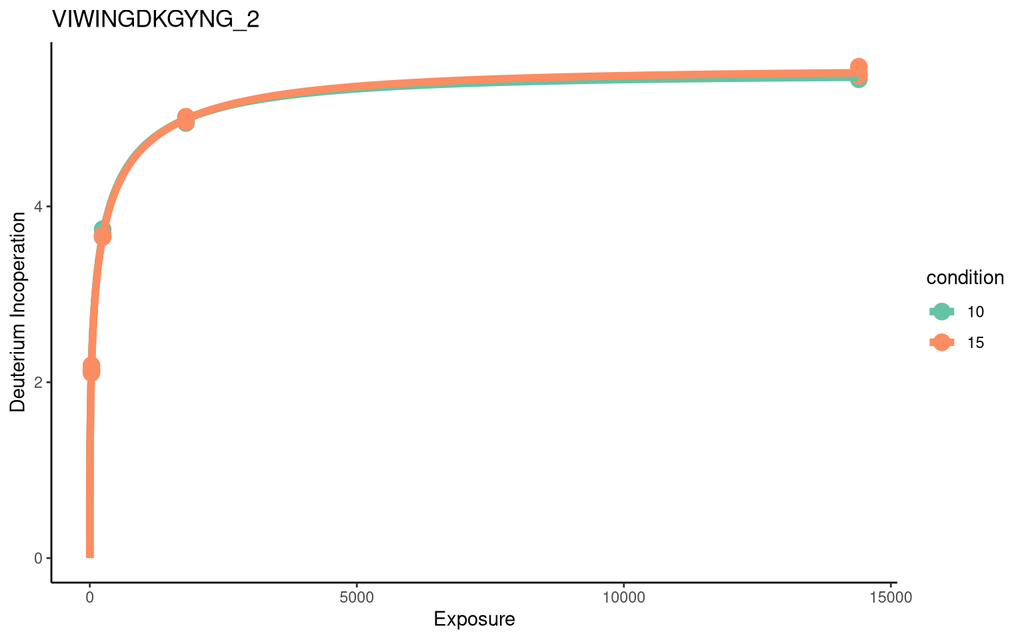

We now wish to apply statistical analysis to these fitted curves. Our approach is an empirical Bayes testing procedure, which borrows information across peptides to stablise variance estimates. Here, we need to provide the original data that was analysed and the `HdxStatModels` class. The following code chunk returns an object of class `HdxStatRes`. This object tell us that statistical analysis was performed using our Functional model.

```r
out <- processFunctional(object = MBPqDF[,1:24], params = res)
out
```

```
## Object of class "HdxStatRes"
## Analysed using Functional model
```

The main slot of interest is the `results` slot which returns quantities of interest such as `p-values` and `fdr` corrected p-values because of multiple testing. The following is the `DataFrame` of interest.

```r
out@results
```

```
## DataFrame with 104 rows and 8 columns
##                           Fstat.Fstat Fstat.numerator Fstat.denomenator
##                                <list>          <list>            <list>
## VIWINGDKGYNG_2                0.70875      0.00109168        0.00154029
## VIWINGDKGYNGL_2             0.0329098     6.18014e-05         0.0018779
## GDKGYNGLAEVG_3               0.980103      0.00129713        0.00132346
## LAEVGKKFEKDTGIKVTVEHPDK_4    0.809885      0.00117025        0.00144496
## AEVGKKFEKDTGIKV_4            0.806449      0.00140588        0.00174329
## ...                               ...             ...               ...
## NAQKGEIMPNIPQM_2              1.74802      0.00425775        0.00243575
## NAQKGEIMPNIPQMSA_2            5.50307        0.013198        0.00239829
## NAQKGEIMPNIPQMSAF_2           7.06683      0.00431371       0.000610416
## PNIPQMSAF_1                  0.905875      0.00277575        0.00306417
## SAFWYAVRTAVINAA_4            0.364674      0.00215102        0.00589847
##                                pvals       fdr ebayes.pvals ebayes.fdr
##                            <numeric> <numeric>    <numeric>  <numeric>
## VIWINGDKGYNG_2              0.597687  0.999959     0.584744   0.999952
## VIWINGDKGYNGL_2             0.997692  0.999959     0.997487   0.999952
## GDKGYNGLAEVG_3              0.445918  0.999959     0.438269   0.999952
## LAEVGKKFEKDTGIKVTVEHPDK_4   0.536935  0.999959     0.525822   0.999952
## AEVGKKFEKDTGIKV_4           0.538920  0.999959     0.520828   0.999952
## ...                              ...       ...          ...        ...
## NAQKGEIMPNIPQM_2          0.18879415 0.6333739   0.16773032  0.6229983
## NAQKGEIMPNIPQMSA_2        0.00554988 0.0443991   0.00430216  0.0394780
## NAQKGEIMPNIPQMSAF_2       0.00177921 0.0231297   0.00269021  0.0378612
## PNIPQMSAF_1               0.48384985 0.9999586   0.44999539  0.9999517
## SAFWYAVRTAVINAA_4         0.83017213 0.9999586   0.80619594  0.9999517
##                           fitcomplete
##                             <integer>
## VIWINGDKGYNG_2                      1
## VIWINGDKGYNGL_2                     2
## GDKGYNGLAEVG_3                      3
## LAEVGKKFEKDTGIKVTVEHPDK_4           4
## AEVGKKFEKDTGIKV_4                   5
## ...                               ...
## NAQKGEIMPNIPQM_2                  100
## NAQKGEIMPNIPQMSA_2                101
## NAQKGEIMPNIPQMSAF_2               102
## PNIPQMSAF_1                       103
## SAFWYAVRTAVINAA_4                 104
```

We can now examine the peptides for which the false discovery rate is less than 0.05

```r
which(out@results$ebayes.fdr < 0.05)
```

[output not shown]

Let us visualise some of these examples:

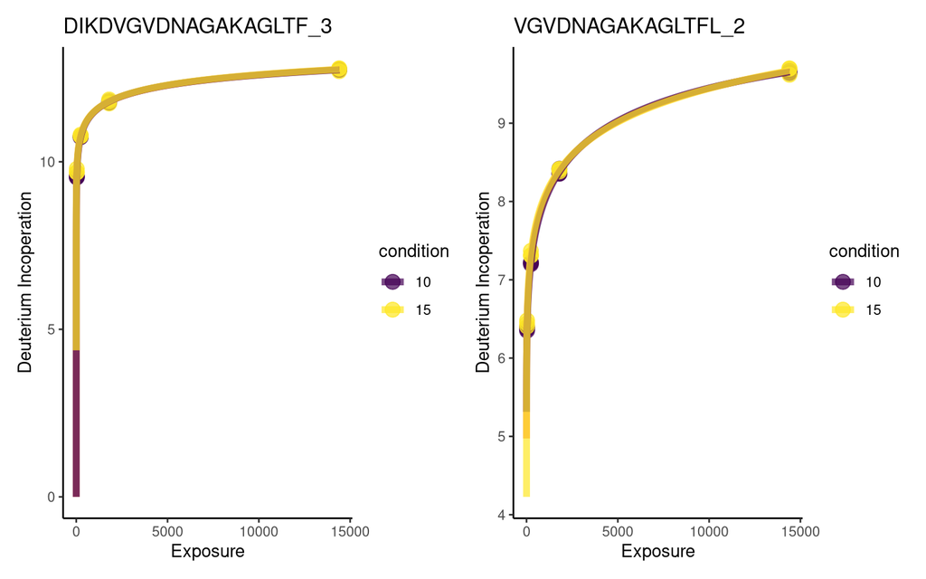

```r
res@statmodels[[42]]@vis + res@statmodels[[45]]@vis
```

As we can see our model has picked up some subtle differences, we can further visualise these using a forest plot. We can see the the functions are very similar as the parameters are almost identical `(a,b,p,d)`. However, we can see that the deuterium differences are lower in 10% structural variant condition.

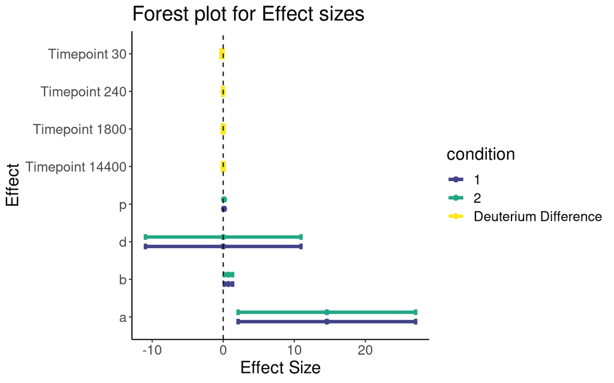

```r
fp <- forestPlot(params = res@statmodels[[42]])
```

```r
knitr::kable(fp$data)
```

|  | Estimate | confL | confU | rownames | condition |
| --- | --- | --- | --- | --- | --- |
| a | 14.5886562 | 2.0924722 | 27.0848401 | a | 1 |
| b | 0.7379217 | 0.1522011 | 1.3236422 | b | 1 |
| d | 0.0000000 | -10.9478603 | 10.9478603 | d | 1 |
| p | 0.1076040 | 0.0256682 | 0.1895398 | p | 1 |
| a1 | 14.5886562 | 2.0924722 | 27.0848401 | a | 2 |
| b1 | 0.7379217 | 0.1522011 | 1.3236422 | b | 2 |
| d1 | 0.0000000 | -10.9478603 | 10.9478603 | d | 2 |
| p1 | 0.1076040 | 0.0256682 | 0.1895398 | p | 2 |
| 1 | -0.1683333 | -0.3086635 | -0.0280032 | Timepoint 30 | Deuterium Difference |
| 2 | -0.0333333 | -0.0854565 | 0.0187898 | Timepoint 240 | Deuterium Difference |
| 3 | -0.0166667 | -0.1428652 | 0.1095319 | Timepoint 1800 | Deuterium Difference |
| 4 | -0.0116667 | -0.1310199 | 0.1076866 | Timepoint 14400 | Deuterium Difference |

It is also possible to visualize, these plots on a different scale. Of course, changing the natural scaling will emphasis different parts of the plot and could distort interpretation. In particular, if a log transform is used then care should be taken when interpreting values around 0. We suggest examining the numerical values in a forest plot or table alongside any transformation of the variables. We suggest using the `pseudo log transform` as this allows control the linearity of the plot, clearly demonstrating this a choice of visualisation (and not of statistical modelling). The parameter `sigma` below controls the scaling factor of the linear part of the transformation.

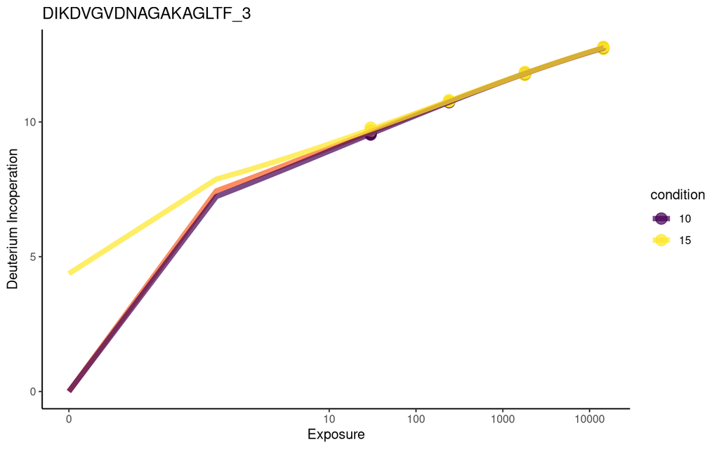

```r
res@statmodels[[42]]@vis + scale_x_continuous(
    trans = pseudo_log_trans(base = 10, sigma = 0.01), breaks = c(0, 10^(1:7)))
```

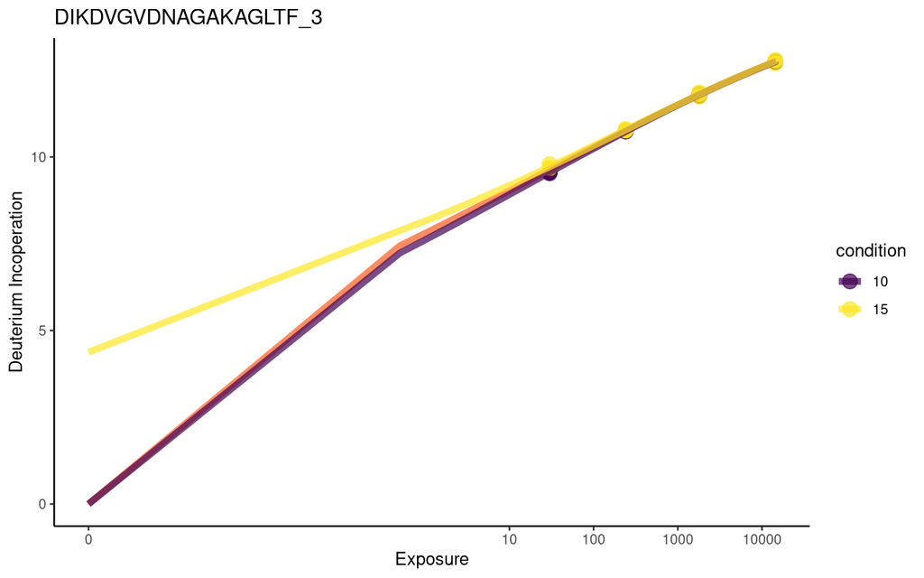

```r
res@statmodels[[42]]@vis + scale_x_continuous(
    trans = pseudo_log_trans(base = 10, sigma = 0.0001), breaks = c(0, 10^(1:7)))
```

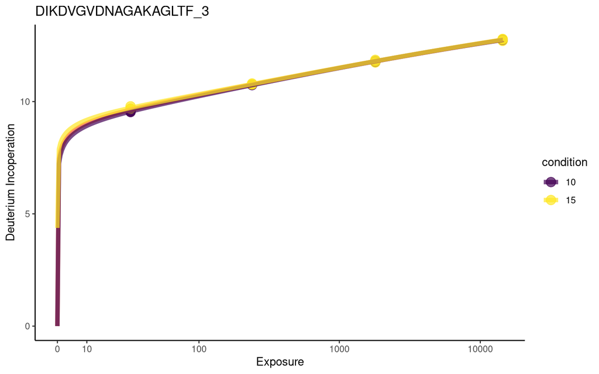

```r
res@statmodels[[42]]@vis + scale_x_continuous(
    trans = pseudo_log_trans(base = 10, sigma = 10), breaks = c(0, 10^(1:7)))
```

Let’s us now have a look a situation where the changes are more dramatic.

```r
res_wt <- fitUptakeKinetics(object = MBPqDF[, c(61:100)],
                            feature = rownames(MBPqDF[, c(61:100)])[[1]],
                            start = list(a = NULL, b = 0.001,  d = NULL, p = 1))
```

[output not shown]

[output cut: 17 more lines]

[output not shown]

```r
out_wt <- processFunctional(object = MBPqDF[, c(61:100)], params = res_wt)
```

We can visualise some of the result and generate plots.

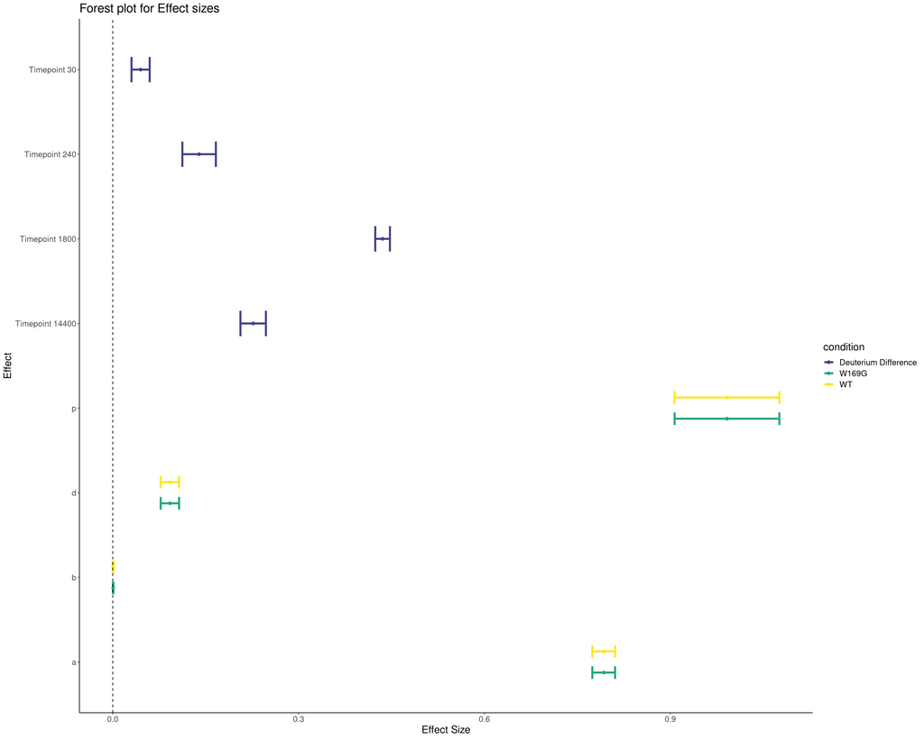

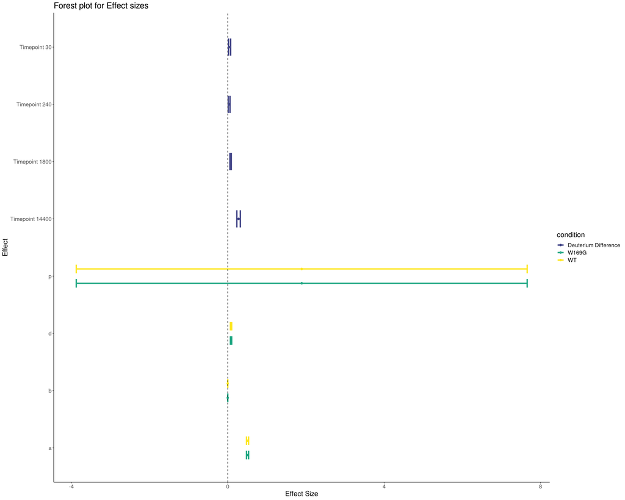

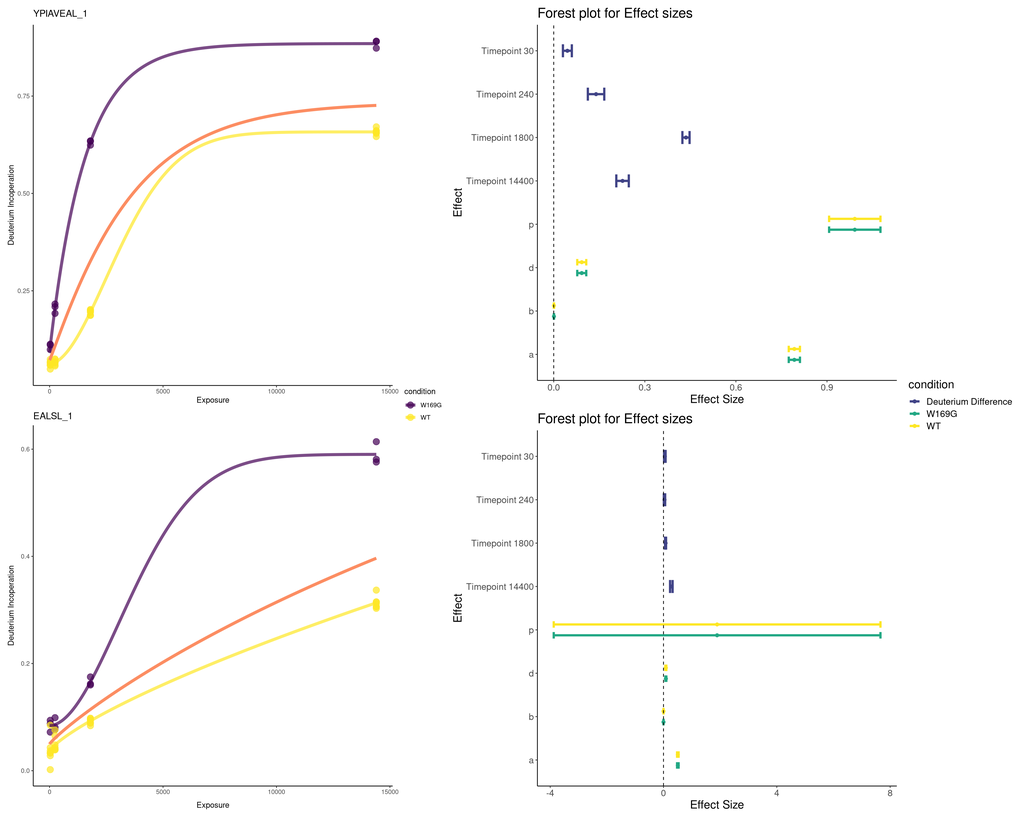

```r
res_wt@statmodels[[27]]@vis/res_wt@statmodels[[28]]@vis + plot_layout(guides = "collect")|(forestPlot(params = res_wt@statmodels[[27]], condition = c("WT", "W169G"))/forestPlot(params = res_wt@statmodels[[28]], condition = c("WT", "W169G")) + plot_layout(guides = "collect")) +
    plot_annotation(tag_levels = 'a') +  plot_layout(widths = c(1, 1))
```